# PKPD Analysis

# Figure 2 (in manuscript), plasma levels based on dosage, and the effect of perampanel on seizure burden within 3 months.

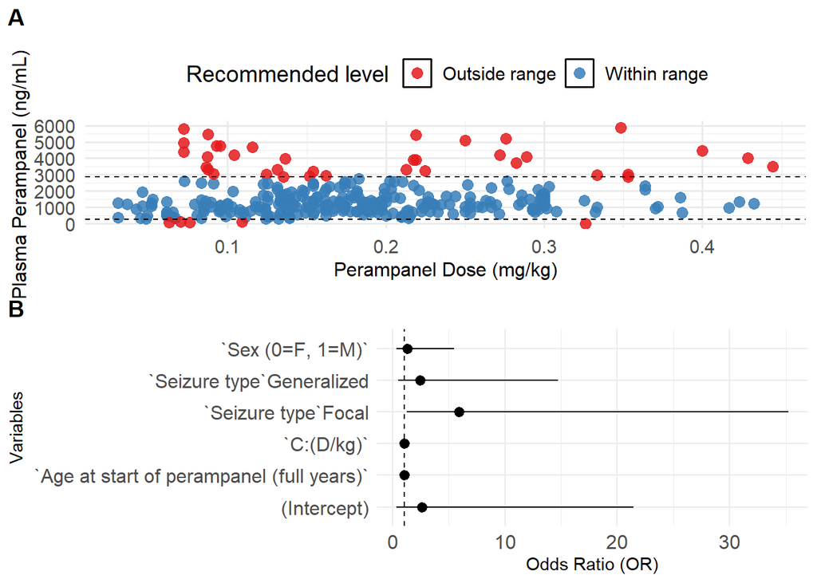

```r
# Top: Dose vs Level, Bottom: Odds Ratios
ggarrange(A, B, labels = c("A", "B"), ncol = 1, nrow = 2, heights = c(1, 1))
```

# Figure 3 (in manuscript), relationship between plasma levels of perampanel and the dose of perampanel.

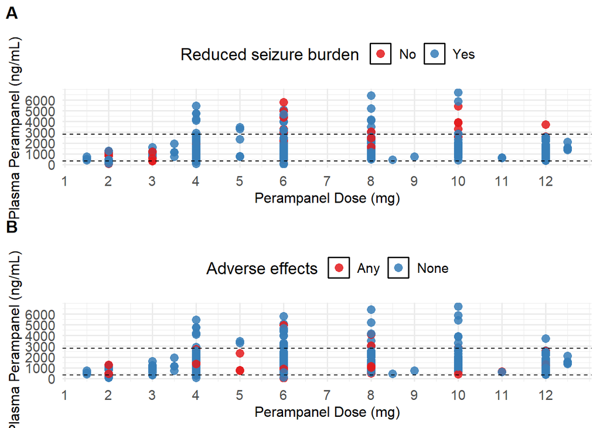

```r
# Top: Seizure-free plot, Bottom: Side effects plot
ggarrange(C, D, labels = c("A", "B"), ncol = 1, nrow = 2, heights = c(1, 1))
```

# Figure 4 (in manuscript), intra-patient variability in C/D-ratio for patients, sorted by increasing age using random patient ID, and adjusted perampanel levels by co-medication type.

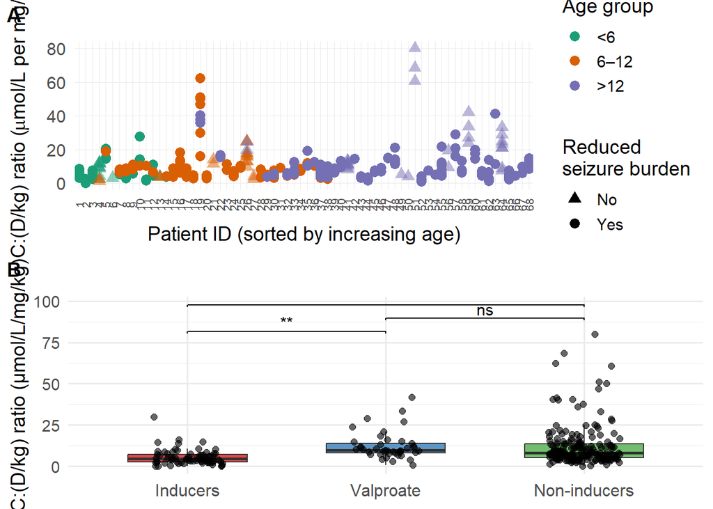

```r
# Top: Seizure-free plot, Bottom: Side effects plot
ggarrange(E, G, labels = c("A", "B"), ncol = 1, nrow = 2, heights = c(1, 1))
```